# Loading and cleaning the data

Sources: - Macroeconomic predictors: https://www.stevanovic.uqam.ca/DS_LCMD.html - Canadian CPI: https://www150.statcan.gc.ca/t1/tbl1/en/tv.action?pid=1810000401 (check at 8:30pm) - FRED-MD data: https://www.stlouisfed.org/research/economists/mccracken/fred-databases

References:

Fortin-Gagnon, O., Leroux, M., Stevanovic, D. and Surprenant, S. (2022), A large Canadian database for macroeconomic analysis. Canadian Journal of Economics/Revue canadienne d’économique, 55: 1799-1833. https://doi.org/10.1111/caje.12618

Statistics Canada. Table 18-10-0004-01 Consumer Price Index, monthly, not seasonally adjusted. DOI: https://doi.org/10.25318/1810000401-eng

## Data is obtained from:

**August 2026** zip file downloaded from the data source

readme.txt content:

These files contain datasets used in: Fortin-Gagnon, Leroux, Stevanovic and Surprenant (2018) A Large Canadian Data for Macroeconomic Analysis.

- `CAN_MD.xlsx`: raw data as collected from StatCan. It starts from 1914 because the CPI series is available from that year
- `TR_CAN_MD.xlsx`: data from CAN_MD.xlsx transformed to induce stationarity.
- `balanced_can_md.xlsx`: stationary and balanced panel starting from 1981M01. Missing values are replaced by EM algorithm.
- `Table_can_md.xlsx`: detailed data description

We use `balanced_can_md.xlsx` as the data is already stationary and balanced panel.

From `Table_can_md.xlsx` we can see that the following variables are discontinued and ends in September 2020. we should remove these from the data source - `CRED_T-discontinued` - `CRED_HOURS_discontinued` - `CRED_MORT_discontinued` - `CRED_CONS_discontinued` - `CRED_BUS_discontinued`

## Outputs (RDS)

Outputs have merged the variables into the following - `main_data_self.rds = can_md + cpi_model_self` - `main_data_official.rds = can_md + cpi_model_official` - `extended_data_self.rds = can_md + cpi_model_self + fred_md` - `extended_data_official.rds = can_md + cpi_model_official + fred_md`

```r
# install packages, should only run once
# install.packages(c("seasonal", "x13binary", "readr", "dplyr", "ggplot2",
#                  "tidyr", "lubridate"), repos = "https://cloud.r-project.org")

library(seasonal)
library(dplyr)
library(readr)
library(ggplot2)
library(tidyr)
library(lubridate)
```

## Canadian Macroeconomic indicators data

```r
# import canadian macroeconomic indicators data
can_md <- read_csv("data/raw/balanced_can_md.csv")
# inspect can_md
dim(can_md)
```

```
## [1] 547 411
```

```r
names(can_md)
```

```
##   [1] "Date"                   "GDP_new"                "BSI_new"
##   [4] "GPI_new"                "SPI_new"                "IP_new"
##   [7] "NDM_new"                "DM_new"                 "OILP_new"
##  [10] "CON_new"                "RT_new"                 "WT_new"
##  [13] "PA_new"                 "FIN_new"                "OIL_CAN_new"
##  [16] "EMP_CAN"                "EMP_SERV_CAN"           "EMP_FOR_OIL_CAN"
##  [19] "EMP_CONS_CAN"           "EMP_SALES_CAN"          "EMP_FIN_CAN"
##  [22] "EMP_MANU_CAN"           "EMP_PART_CAN"           "UNEMP_CAN"
##  [25] "UNEMP_DURA_1.4_CAN"     "UNEMP_DURA_5.13_CAN"    "UNEMP_DURA_14.25_CAN"
##  [28] "UNEMP_DURA_27._CAN"     "UNEMP_DURAvg_CAN_new"   "CLAIMS_CAN"
##  [31] "TOT_HRS_CAN"            "GOOD_HRS_CAN"           "GOOD_OVT_HRS_CAN"
##  [34] "NHOUSE_P_CAN"           "NHOUSE_P_NF"            "NHOUSE_P_PEI"
##  [37] "NHOUSE_P_NS"            "NHOUSE_P_NB"            "NHOUSE_P_QC"
##  [40] "NHOUSE_P_ONT"           "NHOUSE_P_MAN"           "NHOUSE_P_SAS"
##  [43] "NHOUSE_P_ALB"           "NHOUSE_P_BC"            "hstart_CAN_new"
```

[output cut: 122 more lines]

```r
head(can_md) # data starts from 1981-01-01
```

```
## # A tibble: 6 × 411
##   Date         GDP_new   BSI_new   GPI_new   SPI_new    IP_new  NDM_new   DM_new
##   <date>         <dbl>     <dbl>     <dbl>     <dbl>     <dbl>    <dbl>    <dbl>
## 1 1981-01-01  0.00180   0.00145   0.000824  0.00238  -0.000792 -0.00269  0.00150
## 2 1981-02-01  0.00304   0.00346   0.00437   0.00220   0.00422   0.00172  0.0129
## 3 1981-03-01 -0.000820 -0.000917 -0.00283   0.000468  0         0.0112  -0.00277
## 4 1981-04-01  0.0118    0.0148    0.0171    0.00833   0.0189    0.0156   0.0135
## 5 1981-05-01 -0.00836  -0.0120   -0.0108   -0.00680  -0.0176   -0.0173  -0.00398
## 6 1981-06-01 -0.00148  -0.00227   0.00196  -0.00373   0.00472  -0.00412  0.0111
## # ℹ 403 more variables: OILP_new <dbl>, CON_new <dbl>, RT_new <dbl>,
## #   WT_new <dbl>, PA_new <dbl>, FIN_new <dbl>, OIL_CAN_new <dbl>,
## #   EMP_CAN <dbl>, EMP_SERV_CAN <dbl>, EMP_FOR_OIL_CAN <dbl>,
## #   EMP_CONS_CAN <dbl>, EMP_SALES_CAN <dbl>, EMP_FIN_CAN <dbl>,
## #   EMP_MANU_CAN <dbl>, EMP_PART_CAN <dbl>, UNEMP_CAN <dbl>,
## #   UNEMP_DURA_1.4_CAN <dbl>, UNEMP_DURA_5.13_CAN <dbl>,
## #   UNEMP_DURA_14.25_CAN <dbl>, UNEMP_DURA_27._CAN <dbl>, …
```

```r
tail(can_md) # last data is 2026-07-01
```

```
## # A tibble: 6 × 411
##   Date        GDP_new    BSI_new   GPI_new SPI_new   IP_new  NDM_new   DM_new
##   <date>        <dbl>      <dbl>     <dbl>   <dbl>    <dbl>    <dbl>    <dbl>
## 1 2026-02-01 0.00234   0.00293    0.00103  0.00277  0.00920 -0.00537  0.0322
## 2 2026-03-01 0.000337 -0.0000462 -0.00297  0.00143 -0.00101  0.00670 -0.00228
## 3 2026-04-01 0.00505   0.00550    0.0108   0.00314  0.0141  -0.0127   0.0248
## 4 2026-05-01 0.00329   0.00322    0.00673  0.00215  0.00797  0.0235  -0.00388
## 5 2026-06-01 0.00305   0.00293   -0.000653 0.00428 -0.00139 -0.00447  0.0143
## 6 2026-07-01 0.00293   0.00324    0.00339  0.00271  0.00170 -0.00422  0.00831
## # ℹ 403 more variables: OILP_new <dbl>, CON_new <dbl>, RT_new <dbl>,
## #   WT_new <dbl>, PA_new <dbl>, FIN_new <dbl>, OIL_CAN_new <dbl>,
## #   EMP_CAN <dbl>, EMP_SERV_CAN <dbl>, EMP_FOR_OIL_CAN <dbl>,
## #   EMP_CONS_CAN <dbl>, EMP_SALES_CAN <dbl>, EMP_FIN_CAN <dbl>,
## #   EMP_MANU_CAN <dbl>, EMP_PART_CAN <dbl>, UNEMP_CAN <dbl>,
## #   UNEMP_DURA_1.4_CAN <dbl>, UNEMP_DURA_5.13_CAN <dbl>,
## #   UNEMP_DURA_14.25_CAN <dbl>, UNEMP_DURA_27._CAN <dbl>, …
```

```r
# check missing values
missing_count <- colSums(is.na(can_md))
missing_count[missing_count > 0]
```

```
##    CRED_T_discontinued CRED_HOUS_discontinued CRED_MORT_discontinued
##                     70                     70                     70
## CRED_CONS_discontinued   CRE_BUS_discontinued
##                     70                     70
```

```r
sum(is.na(can_md))
```

```
## [1] 350
```

```r
# check duplicates
sum(duplicated(can_md$Date))
```

```
## [1] 0
```

```r
range(can_md$Date)
```

```
## [1] "1981-01-01" "2026-07-01"
```

```r
# check date range, if every month is present
nrow(can_md)
```

```
## [1] 547
```

```r
expected_dates <- seq(
  min(can_md$Date),
  max(can_md$Date),
  by = "month"
)
setdiff(expected_dates, can_md$Date)
```

```
## Date of length 0
```

```r
discontinued_vars <- c(
  "CRED_T_discontinued",
  "CRED_HOUS_discontinued",
  "CRED_MORT_discontinued",
  "CRED_CONS_discontinued",
  "CRE_BUS_discontinued"
)

intersect(discontinued_vars, names(can_md))
```

```
## [1] "CRED_T_discontinued"    "CRED_HOUS_discontinued" "CRED_MORT_discontinued"
## [4] "CRED_CONS_discontinued" "CRE_BUS_discontinued"
```

```r
can_md <- can_md %>%
  select(-any_of(discontinued_vars))

# check whether removed
sum(is.na(can_md))
```

```
## [1] 0
```

```r
# rename variables to standardise across datasets
can_md <- can_md %>%
  rename(date = Date) %>%
  mutate(date = as.Date(date)) %>%
  arrange(date) %>%
  rename_with(
    ~ paste0("CAN_", .x),
    -date
  )

class(can_md$date)
```

```
## [1] "Date"
```

```r
range(can_md$date)
```

```
## [1] "1981-01-01" "2026-07-01"
```

```r
sum(duplicated(can_md$date))
```

```
## [1] 0
```

```r
dim(can_md)
```

```
## [1] 547 406
```

```r
names(can_md)
```

```
##   [1] "date"                     "CAN_GDP_new"
##   [3] "CAN_BSI_new"              "CAN_GPI_new"
##   [5] "CAN_SPI_new"              "CAN_IP_new"
##   [7] "CAN_NDM_new"              "CAN_DM_new"
##   [9] "CAN_OILP_new"             "CAN_CON_new"
##  [11] "CAN_RT_new"               "CAN_WT_new"
##  [13] "CAN_PA_new"               "CAN_FIN_new"
##  [15] "CAN_OIL_CAN_new"          "CAN_EMP_CAN"
##  [17] "CAN_EMP_SERV_CAN"         "CAN_EMP_FOR_OIL_CAN"
##  [19] "CAN_EMP_CONS_CAN"         "CAN_EMP_SALES_CAN"
##  [21] "CAN_EMP_FIN_CAN"          "CAN_EMP_MANU_CAN"
##  [23] "CAN_EMP_PART_CAN"         "CAN_UNEMP_CAN"
##  [25] "CAN_UNEMP_DURA_1.4_CAN"   "CAN_UNEMP_DURA_5.13_CAN"
##  [27] "CAN_UNEMP_DURA_14.25_CAN" "CAN_UNEMP_DURA_27._CAN"
##  [29] "CAN_UNEMP_DURAvg_CAN_new" "CAN_CLAIMS_CAN"
```

[output cut: 188 more lines]

## CPI Data

Testing unseasonally adjusted data -> ARIMA adjustment -> compare against officially seasonally adjusted data. Unsure of which one to use…

```r
# import canadian CPI data
cpi_raw <- read_csv("data/raw/1810000401_databaseLoadingData.csv",
                    show_col_types = FALSE)
cpi_official_raw <- read_csv("data/raw/1810000601_databaseLoadingData.csv",
                    show_col_types = FALSE)
```

```r
# clean column headers
head(cpi_raw)
```

```
## # A tibble: 6 × 15
##   REF_DATE GEO    DGUID        Products and product…¹ UOM   UOM_ID SCALAR_FACTOR
##   <chr>    <chr>  <chr>        <chr>                  <chr>  <dbl> <chr>
## 1 1981-01  Canada 2016A000011… All-items              2002…     17 units
## 2 1981-02  Canada 2016A000011… All-items              2002…     17 units
## 3 1981-03  Canada 2016A000011… All-items              2002…     17 units
## 4 1981-04  Canada 2016A000011… All-items              2002…     17 units
## 5 1981-05  Canada 2016A000011… All-items              2002…     17 units
## 6 1981-06  Canada 2016A000011… All-items              2002…     17 units
## # ℹ abbreviated name: ¹`Products and product groups`
## # ℹ 8 more variables: SCALAR_ID <dbl>, VECTOR <chr>, COORDINATE <dbl>,
## #   VALUE <dbl>, STATUS <lgl>, SYMBOL <lgl>, TERMINATED <lgl>, DECIMALS <dbl>
```

```r
head(cpi_official_raw)
```

```
## # A tibble: 6 × 15
##   REF_DATE GEO    DGUID        Products and product…¹ UOM   UOM_ID SCALAR_FACTOR
##   <chr>    <chr>  <chr>        <chr>                  <chr>  <dbl> <chr>
## 1 1992-01  Canada 2016A000011… All-items              2002…     17 units
## 2 1992-02  Canada 2016A000011… All-items              2002…     17 units
## 3 1992-03  Canada 2016A000011… All-items              2002…     17 units
## 4 1992-04  Canada 2016A000011… All-items              2002…     17 units
## 5 1992-05  Canada 2016A000011… All-items              2002…     17 units
## 6 1992-06  Canada 2016A000011… All-items              2002…     17 units
## # ℹ abbreviated name: ¹`Products and product groups`
## # ℹ 8 more variables: SCALAR_ID <dbl>, VECTOR <chr>, COORDINATE <dbl>,
## #   VALUE <dbl>, STATUS <lgl>, SYMBOL <lgl>, TERMINATED <lgl>, DECIMALS <dbl>
```

```r
cpi <- cpi_raw %>%
  transmute(
    date = as.Date(paste0(REF_DATE, "-01")),
    cpi = as.numeric(VALUE)
  ) %>%
  arrange(date)

cpi_official <- cpi_official_raw %>%
  transmute(
    date = as.Date(paste0(REF_DATE, "-01")),
    cpi_official = as.numeric(VALUE)
  ) %>%
  arrange(date)

head(cpi)
```

```
## # A tibble: 6 × 2
##   date         cpi
##   <date>     <dbl>
## 1 1981-01-01  46.9
## 2 1981-02-01  47.4
## 3 1981-03-01  48
## 4 1981-04-01  48.3
## 5 1981-05-01  48.7
## 6 1981-06-01  49.5
```

```r
head(cpi_official)
```

```
## # A tibble: 6 × 2
##   date       cpi_official
##   <date>            <dbl>
## 1 1992-01-01         83.1
## 2 1992-02-01         83.2
## 3 1992-03-01         83.6
## 4 1992-04-01         83.7
## 5 1992-05-01         83.9
## 6 1992-06-01         84.1
```

```r
range(cpi$date)
```

```
## [1] "1981-01-01" "2026-07-01"
```

```r
range(cpi_official$date)
```

```
## [1] "1992-01-01" "2026-07-01"
```

```r
sum(duplicated(cpi$date))
```

```
## [1] 0
```

```r
sum(duplicated(cpi_official$date))
```

```
## [1] 0
```

Since the data `cpi` is not seasonally adjusted, we use `X-13ARIMA-SEATS` to seasonally adjust.

```r
# check for regularly spaced time series
cpi_ts <- ts(
  cpi$cpi,
  start = c(
    year(min(cpi$date)),
    month(min(cpi$date))
  ),
  frequency = 12
)

start(cpi_ts)
```

```
## [1] 1981    1
```

```r
end(cpi_ts)
```

```
## [1] 2026    7
```

```r
frequency(cpi_ts)
```

```
## [1] 12
```

```r
# to seasonally adjust our CPI, we use ARIMA
# Estimate seasonal adjustment
sa_model <- seas(
  cpi_ts,
  x11 = ""
)

# Extract seasonally adjusted CPI
cpi_sa <- final(sa_model)

# Examine model
summary(sa_model)
```

```
##
## Call:
## seas(x = cpi_ts, x11 = "")
##
## Coefficients:
##                   Estimate Std. Error z value Pr(>|z|)
## LS1991.Jan        0.022606   0.002922   7.736 1.03e-14 ***
## MA-Nonseasonal-01 0.913886   0.017144  53.306  < 2e-16 ***
## MA-Seasonal-12    0.868727   0.022387  38.806  < 2e-16 ***
## ---
## Signif. codes:  0 '***' 0.001 '**' 0.01 '*' 0.05 '.' 0.1 ' ' 1
##
## X11 adj.  ARIMA: (0 2 1)(0 1 1)  Obs.: 547  Transform: log
## AICc: 305.7, BIC: 322.8  QS (no seasonality in final):    0
## Box-Ljung (no autocorr.): 26.96   Shapiro (normality): 0.9853 ***
```

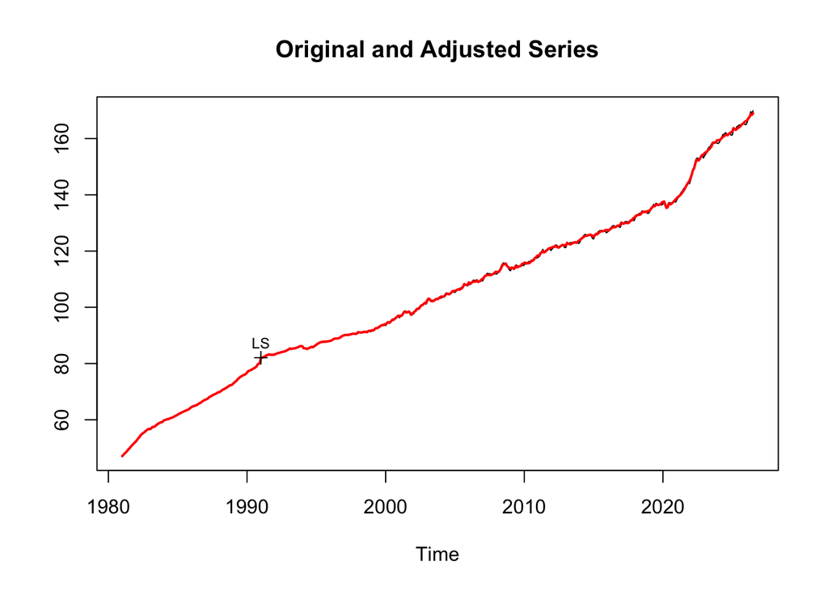

```r
# Plot results
plot(sa_model)
```

```r
cpi_adjusted <- data.frame(
  date = cpi$date,
  cpi_unadjusted = cpi$cpi,
  cpi_adjusted = as.numeric(cpi_sa)
)
```

```r
# we observe the performance of self adjusted CPI
comparison <- cpi_adjusted %>%
  inner_join(cpi_official, by = "date")

range(comparison$date)
```

```
## [1] "1992-01-01" "2026-07-01"
```

```r
nrow(comparison)
```

```
## [1] 415
```

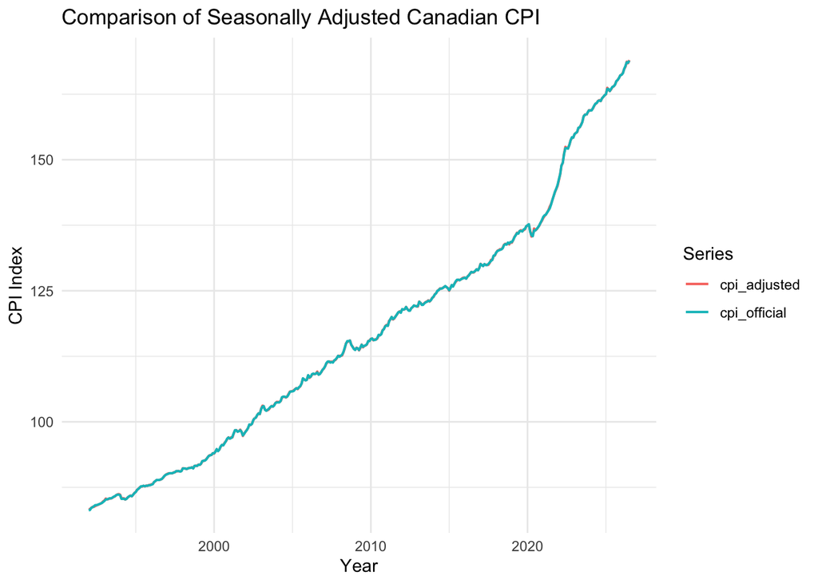

```r
# plot self-adjusted and officially adjusted
comparison_long <- comparison %>%
  select(date, cpi_adjusted, cpi_official) %>%
  pivot_longer(
    cols = -date,
    names_to = "series",
    values_to = "cpi"
  )

ggplot(comparison_long,
       aes(x = date, y = cpi, color = series)) +
  geom_line(linewidth = 0.7) +
  labs(
    title = "Comparison of Seasonally Adjusted Canadian CPI",
    x = "Year",
    y = "CPI Index",
    color = "Series"
  ) +
  theme_minimal()
```

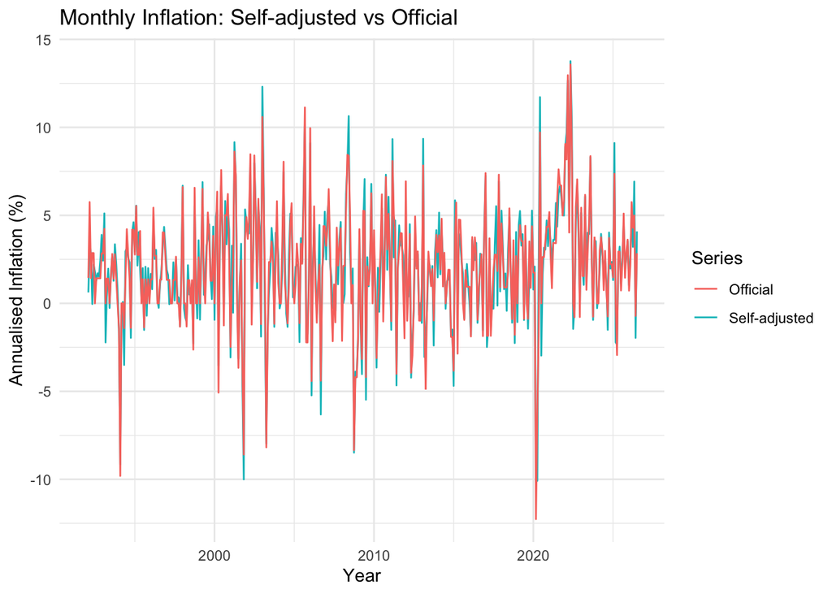

```r
# compare inflation rates
comparison <- comparison %>%
  arrange(date) %>%
  mutate(
    inflation_self =
      1200 * (log(cpi_adjusted) -
              log(lag(cpi_adjusted))),

    inflation_official =
      1200 * (log(cpi_official) -
              log(lag(cpi_official)))
  )

ggplot(comparison, aes(x = date)) +
  geom_line(
    aes(y = inflation_self, color = "Self-adjusted")
  ) +
  geom_line(
    aes(y = inflation_official, color = "Official")
  ) +
  labs(
    title = "Monthly Inflation: Self-adjusted vs Official",
    x = "Year",
    y = "Annualised Inflation (%)",
    color = "Series"
  ) +
  theme_minimal()
```

```r
# quantitative analysis
valid <- comparison %>%
  filter(
    !is.na(inflation_self),
    !is.na(inflation_official)
  )

errors <- valid$inflation_self -
          valid$inflation_official

mae <- mean(abs(errors))
rmse <- sqrt(mean(errors^2))
bias <- mean(errors)

correlation <- cor(
  valid$inflation_self,
  valid$inflation_official
)

data.frame(
  MAE = mae,
  RMSE = rmse,
  Bias = bias,
  Correlation = correlation
)
```

```
##        MAE     RMSE         Bias Correlation
## 1 0.821142 1.051491 -0.005799362   0.9488135
```

## Fred Data

```r
# import fred-md
fred_raw <- read_csv("data/raw/2026-rev-08-MD.csv",
  col_types = cols(.default = col_character())
)

head(fred_raw)
```

```
## # A tibble: 6 × 127
##   sasdate RPI   W875RX1 DPCERA3M086SBEA CMRMTSPLx RETAILx INDPRO IPFPNSS IPFINAL
##   <chr>   <chr> <chr>   <chr>           <chr>     <chr>   <chr>  <chr>   <chr>
## 1 Transf… 5     5       5               5         5       5      5       5
## 2 1/1/19… 2583… 2426    15.188          276676.8… 17689.… 21.99… 23.6312 22.5507
## 3 2/1/19… 2593… 2434.8  15.346          278713.9… 17819.… 22.43… 23.9501 22.7461
## 4 3/1/19… 2610… 2452.7  15.491          277775.2… 17967.… 22.75… 24.0951 22.8577
## 5 4/1/19… 2627… 2470    15.435          283362.7… 17978.… 23.23… 24.4431 23.1926
## 6 5/1/19… 2642… 2486.4  15.622          285307.2… 18119.… 23.58… 24.646  23.4159
## # ℹ 118 more variables: IPCONGD <chr>, IPDCONGD <chr>, IPNCONGD <chr>,
## #   IPBUSEQ <chr>, IPMAT <chr>, IPDMAT <chr>, IPNMAT <chr>, IPMANSICS <chr>,
## #   IPB51222S <chr>, IPFUELS <chr>, CUMFNS <chr>, HWI <chr>, HWIURATIO <chr>,
## #   CLF16OV <chr>, CE16OV <chr>, UNRATE <chr>, UEMPMEAN <chr>, UEMPLT5 <chr>,
## #   UEMP5TO14 <chr>, UEMP15OV <chr>, UEMP15T26 <chr>, UEMP27OV <chr>,
## #   CLAIMSx <chr>, PAYEMS <chr>, USGOOD <chr>, CES1021000001 <chr>,
## #   USCONS <chr>, MANEMP <chr>, DMANEMP <chr>, NDMANEMP <chr>, SRVPRD <chr>, …
```

```r
# preserve transformation codes
fred_transform <- fred_raw[1, ]
fred_transform
```

```
## # A tibble: 1 × 127
##   sasdate RPI   W875RX1 DPCERA3M086SBEA CMRMTSPLx RETAILx INDPRO IPFPNSS IPFINAL
##   <chr>   <chr> <chr>   <chr>           <chr>     <chr>   <chr>  <chr>   <chr>
## 1 Transf… 5     5       5               5         5       5      5       5
## # ℹ 118 more variables: IPCONGD <chr>, IPDCONGD <chr>, IPNCONGD <chr>,
## #   IPBUSEQ <chr>, IPMAT <chr>, IPDMAT <chr>, IPNMAT <chr>, IPMANSICS <chr>,
## #   IPB51222S <chr>, IPFUELS <chr>, CUMFNS <chr>, HWI <chr>, HWIURATIO <chr>,
## #   CLF16OV <chr>, CE16OV <chr>, UNRATE <chr>, UEMPMEAN <chr>, UEMPLT5 <chr>,
## #   UEMP5TO14 <chr>, UEMP15OV <chr>, UEMP15T26 <chr>, UEMP27OV <chr>,
## #   CLAIMSx <chr>, PAYEMS <chr>, USGOOD <chr>, CES1021000001 <chr>,
## #   USCONS <chr>, MANEMP <chr>, DMANEMP <chr>, NDMANEMP <chr>, SRVPRD <chr>, …
```

```r
fred_md <- fred_raw %>%
  slice(-1) %>%                     # remove transformation codes
  rename(date = sasdate) %>%        # rename column to standardise
  mutate(date = as.Date(date, format = "%m/%d/%Y")) %>%
  filter(date >= as.Date("1981-01-01"))  %>% # filter for the dates we need
  rename_with(
    ~ paste0("US_", .x),
    -date
  )
```

```r
dim(fred_md)
```

```
## [1] 547 127
```

```r
names(fred_md)
```

```
##   [1] "date"               "US_RPI"             "US_W875RX1"
##   [4] "US_DPCERA3M086SBEA" "US_CMRMTSPLx"       "US_RETAILx"
##   [7] "US_INDPRO"          "US_IPFPNSS"         "US_IPFINAL"
##  [10] "US_IPCONGD"         "US_IPDCONGD"        "US_IPNCONGD"
##  [13] "US_IPBUSEQ"         "US_IPMAT"           "US_IPDMAT"
##  [16] "US_IPNMAT"          "US_IPMANSICS"       "US_IPB51222S"
##  [19] "US_IPFUELS"         "US_CUMFNS"          "US_HWI"
##  [22] "US_HWIURATIO"       "US_CLF16OV"         "US_CE16OV"
##  [25] "US_UNRATE"          "US_UEMPMEAN"        "US_UEMPLT5"
##  [28] "US_UEMP5TO14"       "US_UEMP15OV"        "US_UEMP15T26"
##  [31] "US_UEMP27OV"        "US_CLAIMSx"         "US_PAYEMS"
##  [34] "US_USGOOD"          "US_CES1021000001"   "US_USCONS"
##  [37] "US_MANEMP"          "US_DMANEMP"         "US_NDMANEMP"
##  [40] "US_SRVPRD"          "US_USTPU"           "US_USWTRADE"
##  [43] "US_USTRADE"         "US_USFIRE"          "US_USGOVT"
```

[output cut: 28 more lines]

```r
head(fred_md)
```

```
## # A tibble: 6 × 127
##   date       US_RPI   US_W875RX1 US_DPCERA3M086SBEA US_CMRMTSPLx US_RETAILx
##   <date>     <chr>    <chr>      <chr>              <chr>        <chr>
## 1 1981-01-01 6065.141 5324.9     34.308             564940.157   85439.13831
## 2 1981-02-01 6048.204 5309.3     34.222             562611.438   86550.81492
## 3 1981-03-01 6067.35  5324.6     34.322             556799.255   87076.97498
## 4 1981-04-01 6056.169 5320.2     34.199             557110.472   86515.60344
## 5 1981-05-01 6074.295 5337.2     34.215             553170.395   85879.78478
## 6 1981-06-01 6107.73  5370.9     34.447             551710.44    86666.50977
## # ℹ 121 more variables: US_INDPRO <chr>, US_IPFPNSS <chr>, US_IPFINAL <chr>,
## #   US_IPCONGD <chr>, US_IPDCONGD <chr>, US_IPNCONGD <chr>, US_IPBUSEQ <chr>,
## #   US_IPMAT <chr>, US_IPDMAT <chr>, US_IPNMAT <chr>, US_IPMANSICS <chr>,
## #   US_IPB51222S <chr>, US_IPFUELS <chr>, US_CUMFNS <chr>, US_HWI <chr>,
## #   US_HWIURATIO <chr>, US_CLF16OV <chr>, US_CE16OV <chr>, US_UNRATE <chr>,
## #   US_UEMPMEAN <chr>, US_UEMPLT5 <chr>, US_UEMP5TO14 <chr>, US_UEMP15OV <chr>,
## #   US_UEMP15T26 <chr>, US_UEMP27OV <chr>, US_CLAIMSx <chr>, US_PAYEMS <chr>, …
```

```r
tail(fred_md)
```

```
## # A tibble: 6 × 127
##   date       US_RPI    US_W875RX1 US_DPCERA3M086SBEA US_CMRMTSPLx US_RETAILx
##   <date>     <chr>     <chr>      <chr>              <chr>        <chr>
## 1 2026-02-01 20532.547 16601.6    125.537            1592277      741278
## 2 2026-03-01 20505.57  16598.1    125.879            1589933      754013
## 3 2026-04-01 20440.51  16522      126.13             1580576      759097
## 4 2026-05-01 20483.483 16552.9    126.597            1585740      766192
## 5 2026-06-01 20539.266 16583.2    127.157            1590918      768072
## 6 2026-07-01 20594.712 16614.7    127.167            <NA>         763602
## # ℹ 121 more variables: US_INDPRO <chr>, US_IPFPNSS <chr>, US_IPFINAL <chr>,
## #   US_IPCONGD <chr>, US_IPDCONGD <chr>, US_IPNCONGD <chr>, US_IPBUSEQ <chr>,
## #   US_IPMAT <chr>, US_IPDMAT <chr>, US_IPNMAT <chr>, US_IPMANSICS <chr>,
## #   US_IPB51222S <chr>, US_IPFUELS <chr>, US_CUMFNS <chr>, US_HWI <chr>,
## #   US_HWIURATIO <chr>, US_CLF16OV <chr>, US_CE16OV <chr>, US_UNRATE <chr>,
## #   US_UEMPMEAN <chr>, US_UEMPLT5 <chr>, US_UEMP5TO14 <chr>, US_UEMP15OV <chr>,
## #   US_UEMP15T26 <chr>, US_UEMP27OV <chr>, US_CLAIMSx <chr>, US_PAYEMS <chr>, …
```

## Constructing our target

Metric following Mederios et al., who forecast: 1. Monthly inflation at future month+h (h=1,2,…,12) 2. Accumulated inflation over next h months (h=3,6,12)

```r
head(cpi_adjusted)
```

```
##         date cpi_unadjusted cpi_adjusted
## 1 1981-01-01           46.9     47.09816
## 2 1981-02-01           47.4     47.50002
## 3 1981-03-01           48.0     47.99336
## 4 1981-04-01           48.3     48.33372
## 5 1981-05-01           48.7     48.77688
## 6 1981-06-01           49.5     49.31330
```

```r
head(cpi_official)
```

```
## # A tibble: 6 × 2
##   date       cpi_official
##   <date>            <dbl>
## 1 1992-01-01         83.1
## 2 1992-02-01         83.2
## 3 1992-03-01         83.6
## 4 1992-04-01         83.7
## 5 1992-05-01         83.9
## 6 1992-06-01         84.1
```

Columns: - date - cpi - log_cpi - inflation_mom (historical monthly inflation) - inflation_12m - target_h1 (1-month-ahead forecasting) - target_h3 (3-month-ahead forecasting) - target_h6 (6-month-ahead forecasting) - target_h12 (12-month-ahead forecasting) - accumulated_h3 (realised 3-month accumulated inflation) - accumulated_h6 (realised 6-month accumulated inflation) - accumulated_h12 (realised 12-month accumulated inflation)

```r
construct_inflation <- function(data, cpi_col) {
  data %>%
    arrange(date) %>%
    transmute(
      date,
      cpi = {{ cpi_col }},
      log_cpi = log(cpi),

      # historical inflation
      inflation_mom = log_cpi - lag(log_cpi),
      inflation_12m = log_cpi - lag(log_cpi, 12)
    ) %>%
    mutate(
      # future monthly inflation
      target_h1 = lead(inflation_mom, 1),
      target_h3 = lead(inflation_mom, 3),
      target_h6 = lead(inflation_mom, 6),
      target_h12 = lead(inflation_mom, 12),

      # future accumulated inflation
      accumulated_h3 = lead(log_cpi, 3) - log_cpi,
      accumulated_h6 = lead(log_cpi, 6) - log_cpi,
      accumulated_h12 = lead(log_cpi, 12) - log_cpi
    )
}

# self adjusted seasonality
cpi_model_self <- construct_inflation(cpi_adjusted, cpi_adjusted)

# officially adjusted
cpi_model_official <- construct_inflation(cpi_official, cpi_official)
```

```r
# checks
range(cpi_model_self$date)
```

```
## [1] "1981-01-01" "2026-07-01"
```

```r
range(cpi_model_official$date)
```

```
## [1] "1992-01-01" "2026-07-01"
```

```r
colSums(is.na(cpi_model_self))
```

```
##            date             cpi         log_cpi   inflation_mom   inflation_12m
##               0               0               0               1              12
##       target_h1       target_h3       target_h6      target_h12  accumulated_h3
##               1               3               6              12               3
##  accumulated_h6 accumulated_h12
##               6              12
```

```r
colSums(is.na(cpi_model_official))
```

```
##            date             cpi         log_cpi   inflation_mom   inflation_12m
##               0               0               0               1              12
##       target_h1       target_h3       target_h6      target_h12  accumulated_h3
##               1               3               6              12               3
##  accumulated_h6 accumulated_h12
##               6              12
```

```r
head(cpi_model_self, 3)
```

```
##         date      cpi  log_cpi inflation_mom inflation_12m   target_h1
## 1 1981-01-01 47.09816 3.852234            NA            NA 0.008496170
## 2 1981-02-01 47.50002 3.860730    0.00849617            NA 0.010332520
## 3 1981-03-01 47.99336 3.871063    0.01033252            NA 0.007066826
##     target_h3   target_h6  target_h12 accumulated_h3 accumulated_h6
## 1 0.007066826 0.008568071 0.008584550     0.02589552     0.05452783
## 2 0.009126851 0.009483243 0.009283042     0.02652620     0.05551490
## 3 0.010937393 0.009744989 0.011375172     0.02713107     0.05492737
##   accumulated_h12
## 1       0.1067705
## 2       0.1075573
## 3       0.1086000
```

```r
tail(cpi_model_self, 3)
```

```
##           date      cpi  log_cpi inflation_mom inflation_12m    target_h1
## 545 2026-05-01 168.7024 5.128136   0.005764849    0.03186176 -0.001636590
## 546 2026-06-01 168.4266 5.126500  -0.001636590    0.02754198  0.003407931
## 547 2026-07-01 169.0015 5.129908   0.003407931    0.03002543           NA
##     target_h3 target_h6 target_h12 accumulated_h3 accumulated_h6
## 545        NA        NA         NA             NA             NA
## 546        NA        NA         NA             NA             NA
## 547        NA        NA         NA             NA             NA
##     accumulated_h12
## 545              NA
## 546              NA
## 547              NA
```

```r
head(cpi_model_official, 3)
```

```
## # A tibble: 3 × 12
##   date         cpi log_cpi inflation_mom inflation_12m target_h1 target_h3
##   <date>     <dbl>   <dbl>         <dbl>         <dbl>     <dbl>     <dbl>
## 1 1992-01-01  83.1    4.42      NA                  NA   0.00120   0.00120
## 2 1992-02-01  83.2    4.42       0.00120            NA   0.00480   0.00239
## 3 1992-03-01  83.6    4.43       0.00480            NA   0.00120   0.00238
## # ℹ 5 more variables: target_h6 <dbl>, target_h12 <dbl>, accumulated_h3 <dbl>,
## #   accumulated_h6 <dbl>, accumulated_h12 <dbl>
```

```r
tail(cpi_model_official, 3)
```

```
## # A tibble: 3 × 12
##   date         cpi log_cpi inflation_mom inflation_12m target_h1 target_h3
##   <date>     <dbl>   <dbl>         <dbl>         <dbl>     <dbl>     <dbl>
## 1 2026-05-01  169.    5.13      0.00416         0.0307 -0.000593        NA
## 2 2026-06-01  168.    5.13     -0.000593        0.0277  0.00237         NA
## 3 2026-07-01  169.    5.13      0.00237         0.0294 NA               NA
## # ℹ 5 more variables: target_h6 <dbl>, target_h12 <dbl>, accumulated_h3 <dbl>,
## #   accumulated_h6 <dbl>, accumulated_h12 <dbl>
```

## Time to merge

```r
# All datasets must have a column named "date"
can_md$date <- as.Date(can_md$date)
fred_md$date <- as.Date(fred_md$date)
cpi_model_self$date <- as.Date(cpi_model_self$date)
cpi_model_official$date <- as.Date(cpi_model_official$date)

# Check duplicate dates
sum(duplicated(can_md$date))
```

```
## [1] 0
```

```r
sum(duplicated(fred_md$date))
```

```
## [1] 0
```

```r
sum(duplicated(cpi_model_self$date))
```

```
## [1] 0
```

```r
sum(duplicated(cpi_model_official$date))
```

```
## [1] 0
```

```r
# Check coverage
range(can_md$date)
```

```
## [1] "1981-01-01" "2026-07-01"
```

```r
range(fred_md$date)
```

```
## [1] "1981-01-01" "2026-07-01"
```

```r
range(cpi_model_self$date)
```

```
## [1] "1981-01-01" "2026-07-01"
```

```r
range(cpi_model_official$date)
```

```
## [1] "1992-01-01" "2026-07-01"
```

```r
dim(can_md)
```

```
## [1] 547 406
```

```r
dim(fred_md)
```

```
## [1] 547 127
```

```r
dim(cpi_model_self)
```

```
## [1] 547  12
```

```r
dim(cpi_model_official)
```

```
## [1] 415  12
```

### Main analysis: Canadian macroeconomic indicators + CPI `main_data`

```r
# with self seasonally adjusted - cpi_model
main_data_self <- can_md %>%
  inner_join(
    cpi_model_self,
    by = "date"
  ) %>%
  arrange(date)

dim(main_data_self)
```

```
## [1] 547 417
```

```r
head(main_data_self)
```

```
## # A tibble: 6 × 417
##   date       CAN_GDP_new CAN_BSI_new CAN_GPI_new CAN_SPI_new CAN_IP_new
##   <date>           <dbl>       <dbl>       <dbl>       <dbl>      <dbl>
## 1 1981-01-01    0.00180     0.00145     0.000824    0.00238   -0.000792
## 2 1981-02-01    0.00304     0.00346     0.00437     0.00220    0.00422
## 3 1981-03-01   -0.000820   -0.000917   -0.00283     0.000468   0
## 4 1981-04-01    0.0118      0.0148      0.0171      0.00833    0.0189
## 5 1981-05-01   -0.00836    -0.0120     -0.0108     -0.00680   -0.0176
## 6 1981-06-01   -0.00148    -0.00227     0.00196    -0.00373    0.00472
## # ℹ 411 more variables: CAN_NDM_new <dbl>, CAN_DM_new <dbl>,
## #   CAN_OILP_new <dbl>, CAN_CON_new <dbl>, CAN_RT_new <dbl>, CAN_WT_new <dbl>,
## #   CAN_PA_new <dbl>, CAN_FIN_new <dbl>, CAN_OIL_CAN_new <dbl>,
## #   CAN_EMP_CAN <dbl>, CAN_EMP_SERV_CAN <dbl>, CAN_EMP_FOR_OIL_CAN <dbl>,
## #   CAN_EMP_CONS_CAN <dbl>, CAN_EMP_SALES_CAN <dbl>, CAN_EMP_FIN_CAN <dbl>,
## #   CAN_EMP_MANU_CAN <dbl>, CAN_EMP_PART_CAN <dbl>, CAN_UNEMP_CAN <dbl>,
## #   CAN_UNEMP_DURA_1.4_CAN <dbl>, CAN_UNEMP_DURA_5.13_CAN <dbl>, …
```

```r
tail(main_data_self)
```

```
## # A tibble: 6 × 417
##   date       CAN_GDP_new CAN_BSI_new CAN_GPI_new CAN_SPI_new CAN_IP_new
##   <date>           <dbl>       <dbl>       <dbl>       <dbl>      <dbl>
## 1 2026-02-01    0.00234    0.00293      0.00103      0.00277    0.00920
## 2 2026-03-01    0.000337  -0.0000462   -0.00297      0.00143   -0.00101
## 3 2026-04-01    0.00505    0.00550      0.0108       0.00314    0.0141
## 4 2026-05-01    0.00329    0.00322      0.00673      0.00215    0.00797
## 5 2026-06-01    0.00305    0.00293     -0.000653     0.00428   -0.00139
## 6 2026-07-01    0.00293    0.00324      0.00339      0.00271    0.00170
## # ℹ 411 more variables: CAN_NDM_new <dbl>, CAN_DM_new <dbl>,
## #   CAN_OILP_new <dbl>, CAN_CON_new <dbl>, CAN_RT_new <dbl>, CAN_WT_new <dbl>,
## #   CAN_PA_new <dbl>, CAN_FIN_new <dbl>, CAN_OIL_CAN_new <dbl>,
## #   CAN_EMP_CAN <dbl>, CAN_EMP_SERV_CAN <dbl>, CAN_EMP_FOR_OIL_CAN <dbl>,
## #   CAN_EMP_CONS_CAN <dbl>, CAN_EMP_SALES_CAN <dbl>, CAN_EMP_FIN_CAN <dbl>,
## #   CAN_EMP_MANU_CAN <dbl>, CAN_EMP_PART_CAN <dbl>, CAN_UNEMP_CAN <dbl>,
## #   CAN_UNEMP_DURA_1.4_CAN <dbl>, CAN_UNEMP_DURA_5.13_CAN <dbl>, …
```

```r
# with officially seasonally adjusted - cpi_official
main_data_official <- can_md %>%
  inner_join(
    cpi_model_official,
    by = "date"
  ) %>%
  arrange(date)

dim(main_data_official)
```

```
## [1] 415 417
```

```r
head(main_data_official)
```

```
## # A tibble: 6 × 417
##   date       CAN_GDP_new CAN_BSI_new CAN_GPI_new CAN_SPI_new CAN_IP_new
##   <date>           <dbl>       <dbl>       <dbl>       <dbl>      <dbl>
## 1 1992-01-01   0.00429      0.00477     0.00144     0.00606    0.0105
## 2 1992-02-01  -0.00281     -0.00413    -0.00681    -0.00106    0.00216
## 3 1992-03-01   0.000961     0.00180     0.00183     0.000580  -0.00186
## 4 1992-04-01   0.00207      0.00346    -0.000593    0.00327    0.00897
## 5 1992-05-01   0.0000684   -0.00128    -0.00350     0.00161   -0.000147
## 6 1992-06-01   0.000513     0.000960    0.000812    0.000401  -0.00148
## # ℹ 411 more variables: CAN_NDM_new <dbl>, CAN_DM_new <dbl>,
## #   CAN_OILP_new <dbl>, CAN_CON_new <dbl>, CAN_RT_new <dbl>, CAN_WT_new <dbl>,
## #   CAN_PA_new <dbl>, CAN_FIN_new <dbl>, CAN_OIL_CAN_new <dbl>,
## #   CAN_EMP_CAN <dbl>, CAN_EMP_SERV_CAN <dbl>, CAN_EMP_FOR_OIL_CAN <dbl>,
## #   CAN_EMP_CONS_CAN <dbl>, CAN_EMP_SALES_CAN <dbl>, CAN_EMP_FIN_CAN <dbl>,
## #   CAN_EMP_MANU_CAN <dbl>, CAN_EMP_PART_CAN <dbl>, CAN_UNEMP_CAN <dbl>,
## #   CAN_UNEMP_DURA_1.4_CAN <dbl>, CAN_UNEMP_DURA_5.13_CAN <dbl>, …
```

```r
tail(main_data_official)
```

```
## # A tibble: 6 × 417
##   date       CAN_GDP_new CAN_BSI_new CAN_GPI_new CAN_SPI_new CAN_IP_new
##   <date>           <dbl>       <dbl>       <dbl>       <dbl>      <dbl>
## 1 2026-02-01    0.00234    0.00293      0.00103      0.00277    0.00920
## 2 2026-03-01    0.000337  -0.0000462   -0.00297      0.00143   -0.00101
## 3 2026-04-01    0.00505    0.00550      0.0108       0.00314    0.0141
## 4 2026-05-01    0.00329    0.00322      0.00673      0.00215    0.00797
## 5 2026-06-01    0.00305    0.00293     -0.000653     0.00428   -0.00139
## 6 2026-07-01    0.00293    0.00324      0.00339      0.00271    0.00170
## # ℹ 411 more variables: CAN_NDM_new <dbl>, CAN_DM_new <dbl>,
## #   CAN_OILP_new <dbl>, CAN_CON_new <dbl>, CAN_RT_new <dbl>, CAN_WT_new <dbl>,
## #   CAN_PA_new <dbl>, CAN_FIN_new <dbl>, CAN_OIL_CAN_new <dbl>,
## #   CAN_EMP_CAN <dbl>, CAN_EMP_SERV_CAN <dbl>, CAN_EMP_FOR_OIL_CAN <dbl>,
## #   CAN_EMP_CONS_CAN <dbl>, CAN_EMP_SALES_CAN <dbl>, CAN_EMP_FIN_CAN <dbl>,
## #   CAN_EMP_MANU_CAN <dbl>, CAN_EMP_PART_CAN <dbl>, CAN_UNEMP_CAN <dbl>,
## #   CAN_UNEMP_DURA_1.4_CAN <dbl>, CAN_UNEMP_DURA_5.13_CAN <dbl>, …
```

### Secondary analysis: Fred data + Canadian macroeconomic indicators + CPI `extended_data`

Note: should choose indicators that would be useful, and rename with “US” prefix to avoid confusion

```r
# with self adjusted main_data
extended_data_self <- main_data_self %>%
  left_join(
    fred_md,
    by = "date"
  ) %>%
  arrange(date)

dim(extended_data_self)
```

```
## [1] 547 543
```

```r
head(extended_data_self)
```

```
## # A tibble: 6 × 543
##   date       CAN_GDP_new CAN_BSI_new CAN_GPI_new CAN_SPI_new CAN_IP_new
##   <date>           <dbl>       <dbl>       <dbl>       <dbl>      <dbl>
## 1 1981-01-01    0.00180     0.00145     0.000824    0.00238   -0.000792
## 2 1981-02-01    0.00304     0.00346     0.00437     0.00220    0.00422
## 3 1981-03-01   -0.000820   -0.000917   -0.00283     0.000468   0
## 4 1981-04-01    0.0118      0.0148      0.0171      0.00833    0.0189
## 5 1981-05-01   -0.00836    -0.0120     -0.0108     -0.00680   -0.0176
## 6 1981-06-01   -0.00148    -0.00227     0.00196    -0.00373    0.00472
## # ℹ 537 more variables: CAN_NDM_new <dbl>, CAN_DM_new <dbl>,
## #   CAN_OILP_new <dbl>, CAN_CON_new <dbl>, CAN_RT_new <dbl>, CAN_WT_new <dbl>,
## #   CAN_PA_new <dbl>, CAN_FIN_new <dbl>, CAN_OIL_CAN_new <dbl>,
## #   CAN_EMP_CAN <dbl>, CAN_EMP_SERV_CAN <dbl>, CAN_EMP_FOR_OIL_CAN <dbl>,
## #   CAN_EMP_CONS_CAN <dbl>, CAN_EMP_SALES_CAN <dbl>, CAN_EMP_FIN_CAN <dbl>,
## #   CAN_EMP_MANU_CAN <dbl>, CAN_EMP_PART_CAN <dbl>, CAN_UNEMP_CAN <dbl>,
## #   CAN_UNEMP_DURA_1.4_CAN <dbl>, CAN_UNEMP_DURA_5.13_CAN <dbl>, …
```

```r
tail(extended_data_self)
```

```
## # A tibble: 6 × 543
##   date       CAN_GDP_new CAN_BSI_new CAN_GPI_new CAN_SPI_new CAN_IP_new
##   <date>           <dbl>       <dbl>       <dbl>       <dbl>      <dbl>
## 1 2026-02-01    0.00234    0.00293      0.00103      0.00277    0.00920
## 2 2026-03-01    0.000337  -0.0000462   -0.00297      0.00143   -0.00101
## 3 2026-04-01    0.00505    0.00550      0.0108       0.00314    0.0141
## 4 2026-05-01    0.00329    0.00322      0.00673      0.00215    0.00797
## 5 2026-06-01    0.00305    0.00293     -0.000653     0.00428   -0.00139
## 6 2026-07-01    0.00293    0.00324      0.00339      0.00271    0.00170
## # ℹ 537 more variables: CAN_NDM_new <dbl>, CAN_DM_new <dbl>,
## #   CAN_OILP_new <dbl>, CAN_CON_new <dbl>, CAN_RT_new <dbl>, CAN_WT_new <dbl>,
## #   CAN_PA_new <dbl>, CAN_FIN_new <dbl>, CAN_OIL_CAN_new <dbl>,
## #   CAN_EMP_CAN <dbl>, CAN_EMP_SERV_CAN <dbl>, CAN_EMP_FOR_OIL_CAN <dbl>,
## #   CAN_EMP_CONS_CAN <dbl>, CAN_EMP_SALES_CAN <dbl>, CAN_EMP_FIN_CAN <dbl>,
## #   CAN_EMP_MANU_CAN <dbl>, CAN_EMP_PART_CAN <dbl>, CAN_UNEMP_CAN <dbl>,
## #   CAN_UNEMP_DURA_1.4_CAN <dbl>, CAN_UNEMP_DURA_5.13_CAN <dbl>, …
```

```r
# with officially adjusted main_data
extended_data_official <- main_data_official %>%
  left_join(
    fred_md,
    by = "date"
  ) %>%
  arrange(date)

dim(extended_data_official)
```

```
## [1] 415 543
```

```r
head(extended_data_official)
```

```
## # A tibble: 6 × 543
##   date       CAN_GDP_new CAN_BSI_new CAN_GPI_new CAN_SPI_new CAN_IP_new
##   <date>           <dbl>       <dbl>       <dbl>       <dbl>      <dbl>
## 1 1992-01-01   0.00429      0.00477     0.00144     0.00606    0.0105
## 2 1992-02-01  -0.00281     -0.00413    -0.00681    -0.00106    0.00216
## 3 1992-03-01   0.000961     0.00180     0.00183     0.000580  -0.00186
## 4 1992-04-01   0.00207      0.00346    -0.000593    0.00327    0.00897
## 5 1992-05-01   0.0000684   -0.00128    -0.00350     0.00161   -0.000147
## 6 1992-06-01   0.000513     0.000960    0.000812    0.000401  -0.00148
## # ℹ 537 more variables: CAN_NDM_new <dbl>, CAN_DM_new <dbl>,
## #   CAN_OILP_new <dbl>, CAN_CON_new <dbl>, CAN_RT_new <dbl>, CAN_WT_new <dbl>,
## #   CAN_PA_new <dbl>, CAN_FIN_new <dbl>, CAN_OIL_CAN_new <dbl>,
## #   CAN_EMP_CAN <dbl>, CAN_EMP_SERV_CAN <dbl>, CAN_EMP_FOR_OIL_CAN <dbl>,
## #   CAN_EMP_CONS_CAN <dbl>, CAN_EMP_SALES_CAN <dbl>, CAN_EMP_FIN_CAN <dbl>,
## #   CAN_EMP_MANU_CAN <dbl>, CAN_EMP_PART_CAN <dbl>, CAN_UNEMP_CAN <dbl>,
## #   CAN_UNEMP_DURA_1.4_CAN <dbl>, CAN_UNEMP_DURA_5.13_CAN <dbl>, …
```

```r
tail(extended_data_official)
```

```
## # A tibble: 6 × 543
##   date       CAN_GDP_new CAN_BSI_new CAN_GPI_new CAN_SPI_new CAN_IP_new
##   <date>           <dbl>       <dbl>       <dbl>       <dbl>      <dbl>
## 1 2026-02-01    0.00234    0.00293      0.00103      0.00277    0.00920
## 2 2026-03-01    0.000337  -0.0000462   -0.00297      0.00143   -0.00101
## 3 2026-04-01    0.00505    0.00550      0.0108       0.00314    0.0141
## 4 2026-05-01    0.00329    0.00322      0.00673      0.00215    0.00797
## 5 2026-06-01    0.00305    0.00293     -0.000653     0.00428   -0.00139
## 6 2026-07-01    0.00293    0.00324      0.00339      0.00271    0.00170
## # ℹ 537 more variables: CAN_NDM_new <dbl>, CAN_DM_new <dbl>,
## #   CAN_OILP_new <dbl>, CAN_CON_new <dbl>, CAN_RT_new <dbl>, CAN_WT_new <dbl>,
## #   CAN_PA_new <dbl>, CAN_FIN_new <dbl>, CAN_OIL_CAN_new <dbl>,
## #   CAN_EMP_CAN <dbl>, CAN_EMP_SERV_CAN <dbl>, CAN_EMP_FOR_OIL_CAN <dbl>,
## #   CAN_EMP_CONS_CAN <dbl>, CAN_EMP_SALES_CAN <dbl>, CAN_EMP_FIN_CAN <dbl>,
## #   CAN_EMP_MANU_CAN <dbl>, CAN_EMP_PART_CAN <dbl>, CAN_UNEMP_CAN <dbl>,
## #   CAN_UNEMP_DURA_1.4_CAN <dbl>, CAN_UNEMP_DURA_5.13_CAN <dbl>, …
```

```r
# save data
dir.create(
  "data/processed",
  showWarnings = FALSE,
  recursive = TRUE
)

# main data
saveRDS(main_data_self, "data/processed/main_data_self.rds")
saveRDS(main_data_official, "data/processed/main_data_official.rds")

# secondary data
saveRDS(extended_data_self, "data/processed/extended_data_self.rds")
saveRDS(extended_data_official, "data/processed/extended_data_official.rds")
```